# STA510 - Mandatory Assignment 1

Tommaso Facchin

26 settembre 2026

# 1 Problem 1

## 1.1 d)

```r
a <- 5
n <- 5000

F <- function(x, a) {(3 / 4000) * (10 * (x - a)^2 - (x - a)^3 / 3)}

F_inv <- function(p, a) {
  uniroot(
    function(x) F(x, a) - p,
    lower = a,
    upper = a + 20
  )$root
}

set.seed(42)

u <- runif(n)

wind_speed <- sapply(u, F_inv, a = a)
```

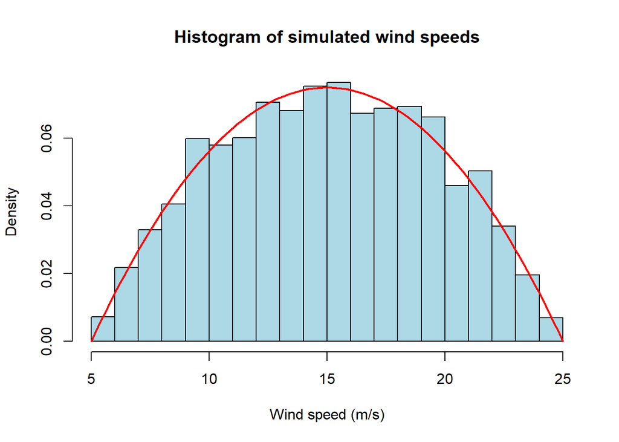

```r
hist(
  wind_speed,
  breaks = "Scott",
  probability = TRUE,
  col = "lightblue",
  main = "Histogram of simulated wind speeds",
  xlab = "Wind speed (m/s)"
)

curve(
  (3 / 4000) * (x - 5) * (25 - x),
  from = 5,
  to = 25,
  add = TRUE,
  col = "red",
  lwd = 2
)
```

The simulated values follow the expected parabolic shape. The density is close to zero near the limits ($5$ m/s and $25$ m/s), and it reaches its maximum around $15$ m/s.

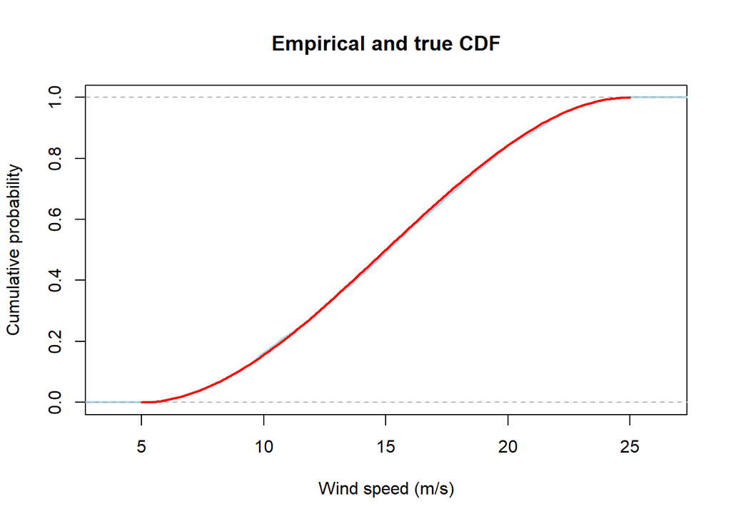

```r
plot(
  ecdf(wind_speed),
  main = "Empirical and true CDF",
  xlab = "Wind speed (m/s)",
  ylab = "Cumulative probability",
  col = "lightblue",
  lwd = 2
)

curve(
  (3 / 4000) * (10 * (x - 5)^2 - (x - 5)^3 / 3),
  from = 5,
  to = 25,
  add = TRUE,
  col = "red",
  lwd = 2
)
```

The empirical CDF is very similar to the true CDF. The empirical CDF is a step function based on the simulated sample, whereas the true CDF is smooth. The two curves are almost overlapping.

## 1.2 e)

### 1.2.1 iii)

The theoretical acceptance rate is

$$\frac{1}{M}
=
\frac{1}{3/2}
=
\boxed{\frac{2}{3}}
\approx0.6667.$$

Approximately 66.67% of the proposed values are expected to be accepted.

To generate 5000 accepted samples, the expected number of proposals is

$$\frac{5000}{2/3}
=
\boxed{7500}.$$

## 1.3 f)

```r
a <- 5
n <- 5000
M <- 3 / 2

wind_ar <- numeric(n)
proposed <- 0
i <- 1

while (i <= n) {

  x <- runif(1, min = a, max = a + 20)

  u <- runif(1)

  acceptance_probability <- (
    (3 / 4000) * (x - a) * (a + 20 - x)
  ) / (M * (1 / 20))

  proposed <- proposed + 1

  if (u <= acceptance_probability) {
    wind_ar[i] <- x
    i <- i + 1
  }
}

empirical_rate <- n / proposed
empirical_rate
```

```
## [1] 0.664187
```

### 1.3.1 i)

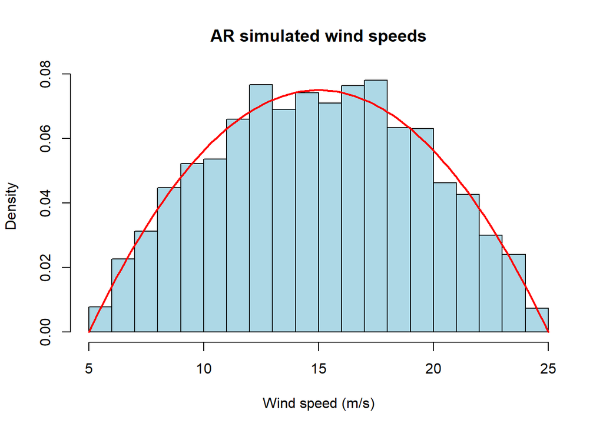

```r
hist(
  wind_ar,
  breaks = "Scott",
  probability = TRUE,
  col = "lightblue",
  main = "AR simulated wind speeds",
  xlab = "Wind speed (m/s)",
  ylab = "Density"
)

curve(
  (3 / 4000) * (x - 5) * (25 - x),
  from = 5,
  to = 25,
  add = TRUE,
  col = "red",
  lwd = 2
)
```

The histogram of the Acceptance-Rejection samples follows the true density well. The simulated values have the expected parabolic shape. Small differences are due to random sampling variation.

### 1.3.2 ii)

The empirical acceptance rate was 0.6642, which is close to the theoretical acceptance rate

$$\frac{1}{M}
\approx0.6667.$$

The small difference is due to random variation in the simulation.

### 1.3.3 iii)

The inverse transform method is preferable when $F^{-1}$ is available or canbe computed efficiently, since every generated uniform value produces one sample. The Acceptance-Rejection method is preferable when the inverse CDF is difficult to obtain but a good proposal distribution is available. Here, AR is reasonably efficient because its theoretical acceptance rate is $2/3$.

# 2 Problem 2

```r
rain <- c(3.1, 7.2, 5.4, 12.0, 8.8, 4.3, 9.6, 6.1, 11.2, 2.9,
7.5, 14.1, 5.0, 9.3, 6.8, 10.4, 3.7, 8.1, 13.5, 4.6,
6.3, 11.8, 7.9, 5.5, 9.0, 12.7, 4.1, 8.4, 6.6, 10.1,
3.4, 7.0, 5.8, 13.2, 9.7, 6.2, 11.5, 4.8, 8.9, 7.3)

sum(rain)
```

```
## [1] 313.8
```

```r
sum(rain)/40
```

```
## [1] 7.845
```

## 2.1 c)

```r
z <- qnorm(0.975)
z
```

```
## [1] 1.959964
```

```r
n <- ceiling((z * mean(rain) / 1)^2)
n
```

```
## [1] 237
```

## 2.2 d)

```r
beta_hat <- mean(rain)
beta_hat
```

```
## [1] 7.845
```

```r
n <- length(rain)
z <- qnorm(0.975)

se_hat <- beta_hat / sqrt(n)
ci <- beta_hat + c(-1, 1) * z * se_hat
ci
```

```
## [1]  5.413854 10.276146
```

We are approximately 95% confident that the true mean rainfall on a wet day lies between 5.41 mm and 10.28 mm.

# 3 Problem 3

## 3.1 a)

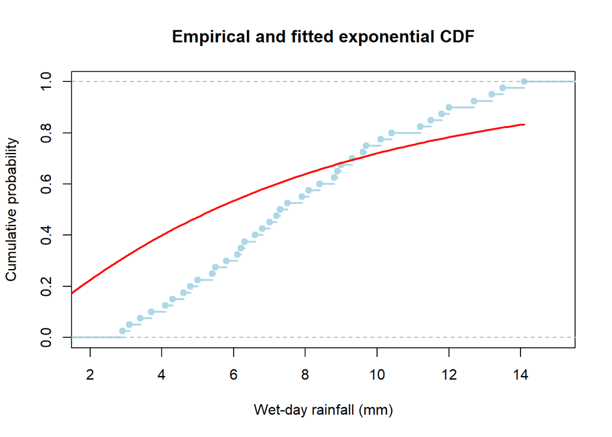

```r
plot(
  ecdf(rain),
  main = "Empirical and fitted exponential CDF",
  xlab = "Wet-day rainfall (mm)",
  ylab = "Cumulative probability",
  col = "lightblue",
  lwd = 2
)

curve(
  pexp(x, rate = 1 / beta_hat),
  from = 0,
  to = max(rain),
  add = TRUE,
  col = "red",
  lwd = 2
)
```

## 3.2 b)

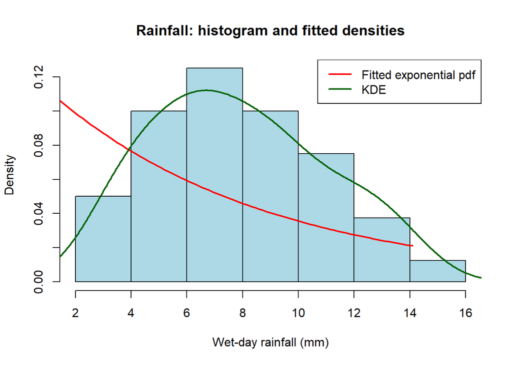

```r
hist(
  rain,
  breaks = "Scott",
  probability = TRUE,
  col = "lightblue",
  main = "Rainfall: histogram and fitted densities",
  xlab = "Wet-day rainfall (mm)",
  ylab = "Density"
)

curve(
  dexp(x, rate = 1 / beta_hat),
  from = 0,
  to = max(rain),
  add = TRUE,
  col = "red",
  lwd = 2
)

lines(
  density(rain),
  col = "darkgreen",
  lwd = 2
)

legend(
  "topright",
  legend = c("Fitted exponential pdf", "KDE"),
  col = c("red", "darkgreen"),
  lwd = 2
)
```

## 3.3 d)

```r
library(MASS)

gamma_fit <- fitdistr(rain, "gamma")
gamma_fit
```

```
##      shape       rate
##   6.2247898   0.7934730
##  (1.3562308) (0.1800429)
```

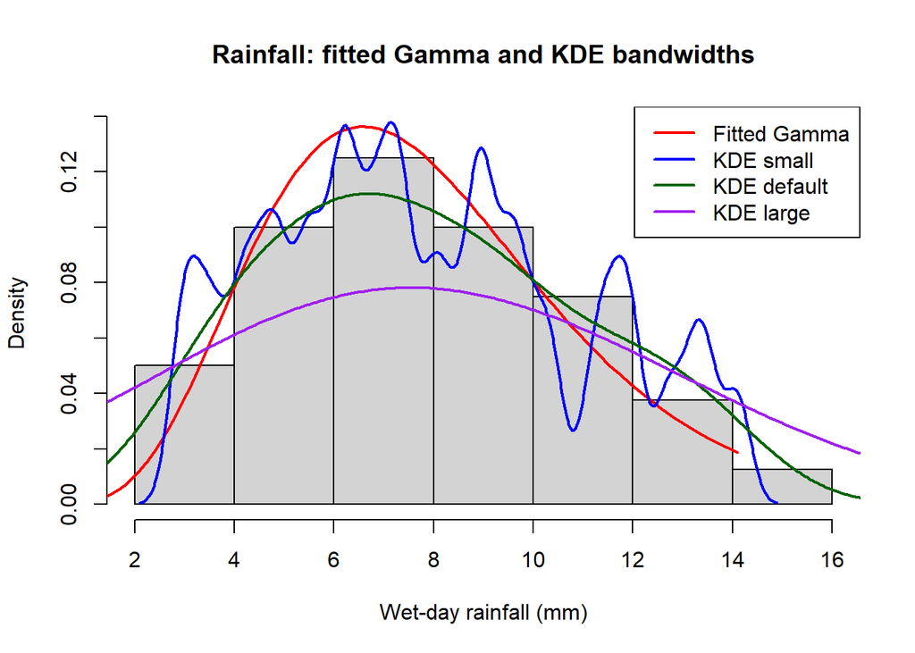

```r
h <- bw.nrd0(rain)

kde_small <- density(rain, bw = 0.2 * h)
kde_default <- density(rain, bw = h)
kde_large <- density(rain, bw = 3 * h)

shape_hat <- gamma_fit$estimate["shape"]
rate_hat <- gamma_fit$estimate["rate"]

hist(
  rain,
  breaks = "Scott",
  probability = TRUE,
  col = "lightgray",
  main = "Rainfall: fitted Gamma and KDE bandwidths",
  xlab = "Wet-day rainfall (mm)",
  ylab = "Density",
  ylim = c(0, max(
    kde_small$y,
    kde_default$y,
    kde_large$y,
    dgamma(seq(0, max(rain), length.out = 200),
           shape = shape_hat, rate = rate_hat)
  ))
)

curve(
  dgamma(x, shape = shape_hat, rate = rate_hat),
  from = 0,
  to = max(rain),
  add = TRUE,
  col = "red",
  lwd = 2
)

lines(kde_small, col = "blue", lwd = 2)
lines(kde_default, col = "darkgreen", lwd = 2)
lines(kde_large, col = "purple", lwd = 2)

legend(
  "topright",
  legend = c("Fitted Gamma", "KDE small",
             "KDE default", "KDE large"),
  col = c("red", "blue", "darkgreen", "purple"),
  lwd = 2
)
```

The fitted Gamma density seems way better than the exponential one.The KDE with a small bandwidth is overfitted, the KDE with large bandwidth is underfitted, while the default one is a good compromise.

# 4 Problem 4

## 4.1 b)

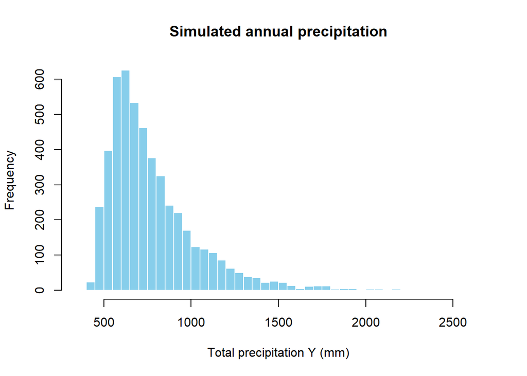

```r
n <- 5000

A <- rnorm(n, mean = 400, sd = 30)
B <- rexp(n, rate = 1 / 250)
C <- runif(n, min = 50, max = 150)
D <- 80 * rbinom(n, size = 1, prob = 0.3)

Y <- A + B + C + D

hist(
  Y,
  breaks = 40,
  main = "Simulated annual precipitation",
  xlab = "Total precipitation Y (mm)",
  col = "skyblue",
  border = "white"
)
```

```r
mean(Y)
```

```
## [1] 777.2885
```

```r
sd(Y)
```

```
## [1] 259.7737
```

From the simulated values the esitimated mean is 777.2885 and sd is 259.7737, very close to the analytical values.

```r
p_est <- mean(Y > 1050)
p_est
```

```
## [1] 0.131
```

13.1% of the 5000 values in the simulation exceed 1050mm. The estimated probability that total annual precipitation exceed 1050mm is .131